# Time Series Homework: Chapter 3 Lesson 2 Key

```r
pacman::p_load(
  tidyverse,  # ggplot, mutate(), cleaning...
  tsibble,    # as_tsibble()
  fable,      # model(...), forecast(), tidy(), glance()...
  feasts,     # ACF(), PACF()
  ggtime,     # autoplot() for tsibbles
  rio,        # import()
  pander,     # pander() markdown tables
  patchwork   # + and / for ggplots
)

pacman::p_load(
  pander,
  kableExtra
)
```

## Data

```r
mortality <- rio::import("https://byuistats.github.io/timeseries/data/mortality_us.xlsx")
```

## Questions

### Question 1 - Context and Measurement (10 points)

The first part of any time series analysis is context. You cannot properly analyze data without knowing what the data is measuring. Without context, the most simple features of data can be obscure and inscrutable. This homework assignment will center around the series below.

Please research the time series. In the spaces below, give the data collection process, unit of analysis, and meaning of each observation for the series.

#### **US Mortality**

https://wonder.cdc.gov/wonder/help/cmf.html#

Note: The data is self-explanatory, don’t get lost in the documentation page.

**NoteAnswer**

**Data Collection Process:**

The CDC collects data on the number of deaths in the US from the Compressed Mortality File which is a data base updated annually.

**Unit of Analysis:**

Deaths per 100,000 people in the United States

**Meaning:**

Each observation is the population, number of deaths and the mortality rate per 100,000 people on an annual level.

### Question 2 - US Mortality Rate: Visualization (30 points)

##### a) Please plot the US Mortality Rate series (mortality per 100,000).

**NoteAnswer**

**Example 1**

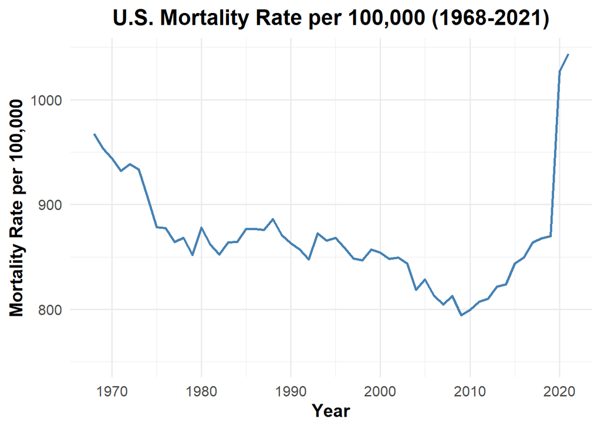

```r
# Clean
mortality <- mortality |>
  rename(mortality_rate = `mort_rate_per_100,000`) |>
  as_tsibble(index = year)

# Visual
ggplot(mortality, aes(x = year, y = mortality_rate)) +
  geom_line(color = "steelblue", size = 1) +
  labs(
    title = "U.S. Mortality Rate per 100,000 (1968-2021)",
    x = "Year",
    y = "Mortality Rate per 100,000",
  ) +
  theme_minimal(base_size = 15) +
  theme(
    plot.title = element_text(hjust = 0.5, face = "bold"),
    axis.title.x = element_text(face = "bold"),
    axis.title.y = element_text(face = "bold"),
    plot.caption = element_text(hjust = 0.5, face = "italic", color = "gray40")
  ) +
  ylim(750, max(mortality$mortality_rate))  # Set y-axis starting from 800
```

**Example 2**

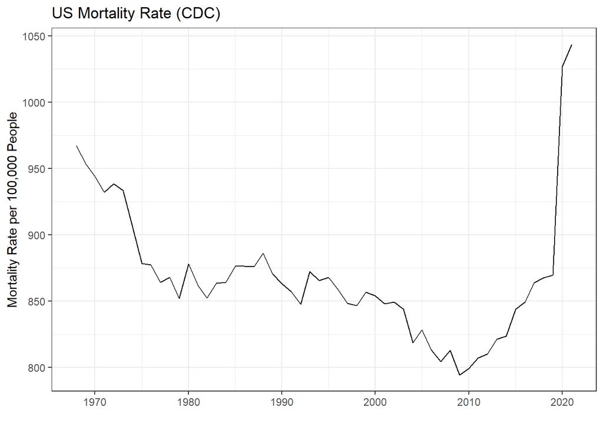

```r
# Calculate everything upfront
ewma_models <- mortality |>
  model(
    SS1PE = ETS(mortality_rate, opt_crit = "amse"), # Defaults to ANN
    pt2   = ETS(mortality_rate ~ trend("N", alpha = 0.2)),
    one_n = ETS(mortality_rate ~
      trend("N", alpha = 1 / nrow(mortality), beta = 0)
    )
  )

# Make the models plot-able
#   by turning it into a dable (basically a tibble with specific columns)
models_dable <- ewma_models |> augment()

# save the plot for later
pl <- ggplot(mortality, aes(year, mortality_rate)) +
  geom_line() +
  labs(
    x = "",
    y = "Mortality Rate per 100,000 People",
    title = "US Mortality Rate (CDC)",
    color = "Alpha"
  ) +
  theme_bw() +
  scale_color_manual(values = c(
    "Optimized" = "orange",
    "0.2" = "red",
    "1/n" = "purple"
  ))

# show the plot
pl
```

##### b) Use the exponential smoothing method to model the US Mortality Rate series. Use the smoothing parameter that R calculates by minimizing the SS1PE. Add it to the plot in 2a

**NoteAnswer**

**Example 1**

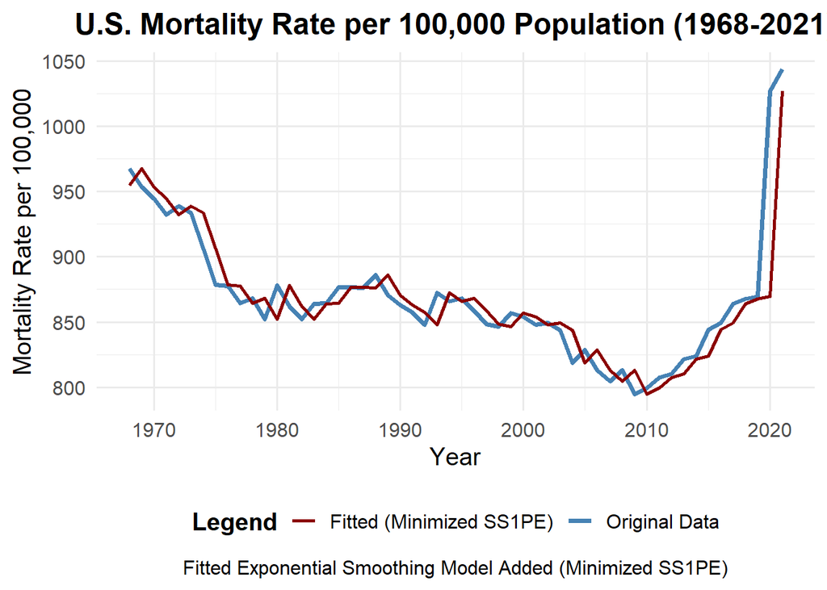

```r
# Model
model_ss1pe <- mortality |>
  model(Additive = ETS(
    mortality_rate ~
      error("A") +
      trend("N") +
      season("N"),     # No trend or seasonality, pure EWMA
    opt_crit = "amse"  # Minimize SS1PE using AMSE
  ))

fitted_values <- fitted(model_ss1pe)

# Add the fitted values to the plot and include a legend
ggplot() +
  geom_line(
    data = mortality,
    aes(x = year, y = mortality_rate, color = "Original Data"),
    size = 1.3
  ) +
  geom_line(
    data = fitted_values,
    aes(x = year, y = .fitted, color = "Fitted (Minimized SS1PE)"),
    size = 1
  ) +
  scale_color_manual(
    name = "Legend",
    values = c(
      "Original Data" = "steelblue",
      "Fitted (Minimized SS1PE)" = "darkred"
    )
  ) +
  labs(
    title = "U.S. Mortality Rate per 100,000 Population (1968-2021)",
    x = "Year",
    y = "Mortality Rate per 100,000",
    caption = "Fitted Exponential Smoothing Model Added (Minimized SS1PE)"
  ) +
  theme_minimal(base_size = 15) +
  theme(
    plot.title = element_text(hjust = 0.5, face = "bold"),
    plot.caption = element_text(hjust = 0.5),
    legend.position = "bottom",
    legend.title = element_text(face = "bold")
  )
```

**Example 2**

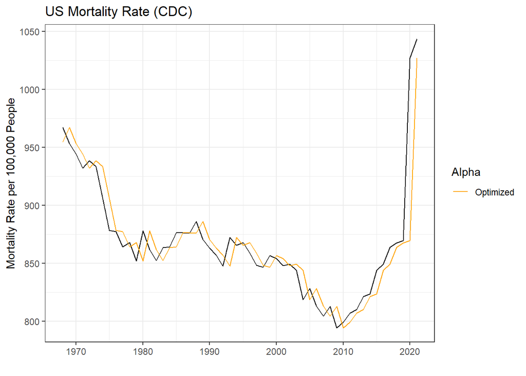

```r
# add new line to plot
pl <- pl +
  geom_line(
    data = models_dable |> filter(.model == "SS1PE"),
    aes(year, .fitted, col = "Optimized")
  )

# show the plot
pl
```

##### c) Please repeat the modeling above but instead choose a smoothing parameter value $\alpha=0.2$. Add it to the plot in 2a

**NoteAnswer**

**Example 1**

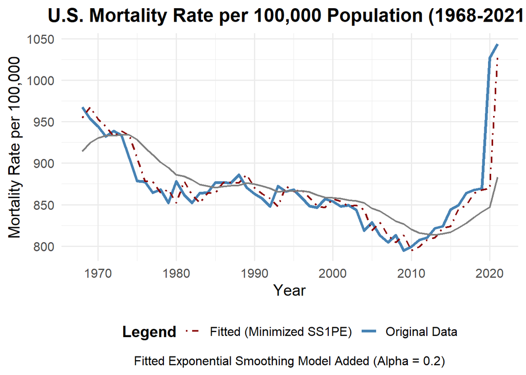

```r
model_pt2 <- mortality |>
  model(Additive = ETS(
    mortality_rate ~
      error("A") +
      trend("N", alpha = 0.2, beta = 0) +
      season("N"),
    opt_crit = "amse"
  ))

fitted_values_pt2 <- fitted(model_pt2)

# Add the fitted values to the plot and include a legend
ggplot() +
  geom_line(
    data = mortality,
    aes(x = year, y = mortality_rate, color = "Original Data"),
    size = 1.3
  ) +
  geom_line(
    data = fitted_values,
    aes(x = year, y = .fitted, color = "Fitted (Minimized SS1PE)"),
    size = 0.75,
    linetype = "dotdash"
  ) +
  geom_line(
    data = fitted_values_pt2,
    aes(x = year, y = .fitted, color = "Fitted (Alpha = 0.2)"),
    size = 0.75
  ) +
  scale_color_manual(
    name = "Legend",
    values = c(
      "Original Data" = "steelblue",
      "Fitted (Minimized SS1PE)" = "darkred",
      "Fitted (α = 0.2)" = "darkgreen"
    )
  ) +
  labs(
    title = "U.S. Mortality Rate per 100,000 Population (1968-2021)",
    x = "Year",
    y = "Mortality Rate per 100,000",
    caption = "Fitted Exponential Smoothing Model Added (Alpha = 0.2)"
  ) +
  theme_minimal(base_size = 15) +
  theme(
    plot.title = element_text(hjust = 0.5, face = "bold"),
    plot.subtitle = element_text(hjust = 0.5),
    plot.caption = element_text(hjust = 0.5),
    legend.position = "bottom",
    legend.title = element_text(face = "bold")
  )
```

**Example 2**

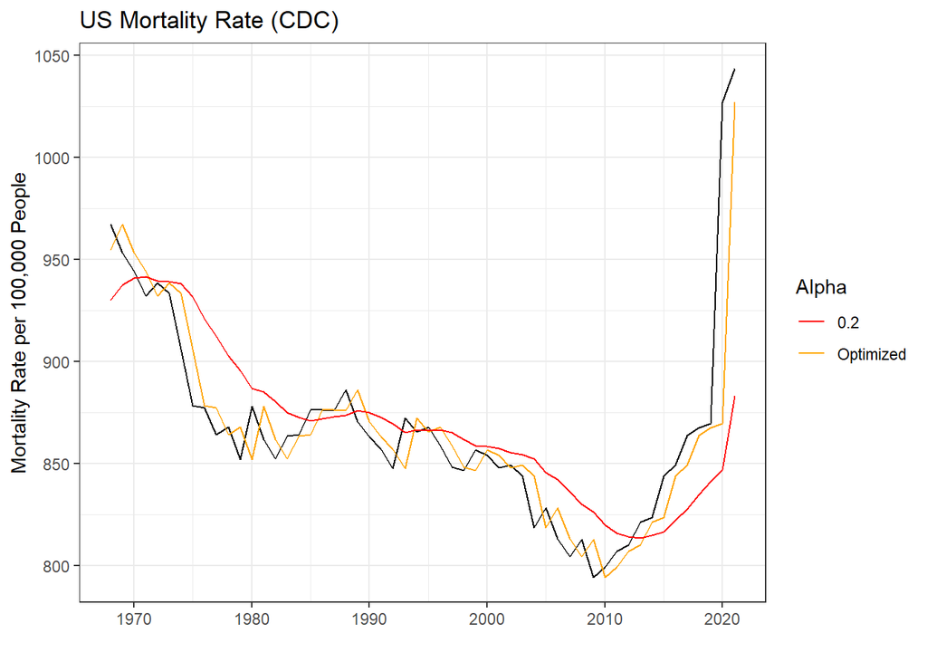

```r
# add new line to plot
pl <- pl +
  geom_line(
    data = models_dable |> filter(.model == "pt2"),
    aes(year, .fitted, col = "0.2")
  )

# show plot
pl
```

##### d) Please repeat the modeling above but instead choose a smoothing parameter value $\alpha=\frac{1}{n}$.Add it to the plot in 2a

**NoteAnswer**

**Example 1**

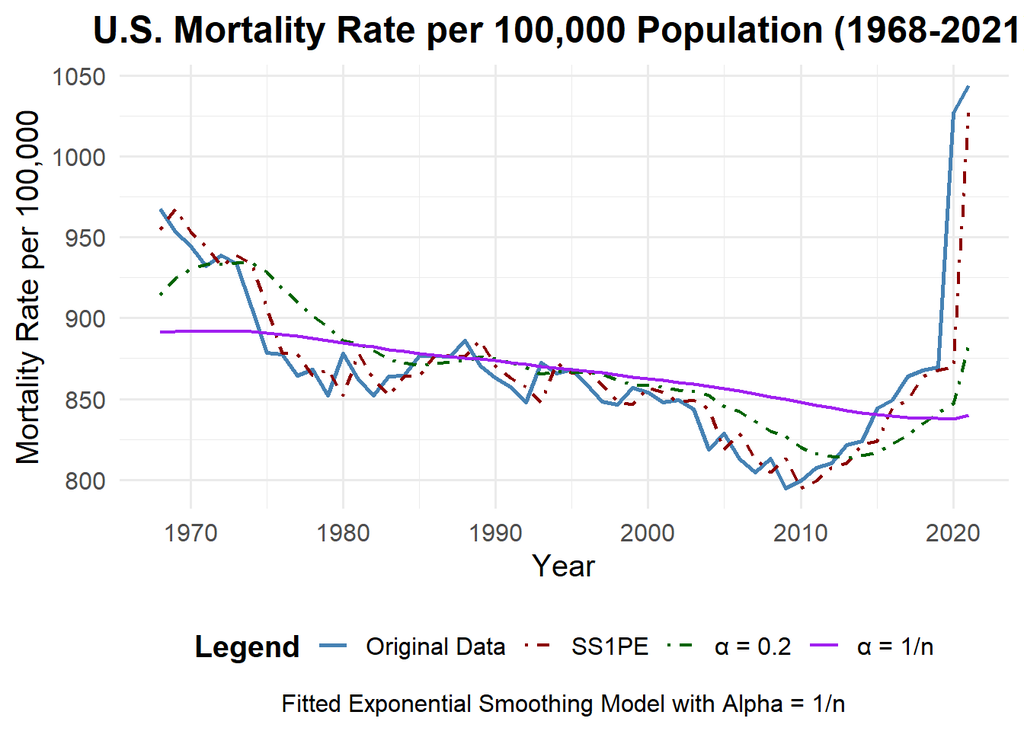

```r
n <- nrow(mortality) # To calculate 1 / n

model_1n <- mortality |>
  model(
    Additive = ETS(
      mortality_rate ~
        error("A") +
        trend("A" , alpha = 1 / n, beta = 0) +
        season("N"),
      opt_crit = "amse"
    )  # Minimize SS1PE using AMSE
  )

fitted_values_1n <- fitted(model_1n)

# Add the fitted values to the plot and include a legend
ggplot() +
  geom_line(
    data = mortality,
    aes(x = year, y = mortality_rate, color = "Original Data"),
    size = 1
  ) +
  geom_line(
    data = fitted_values,
    aes(x = year, y = .fitted, color = "SS1PE"),
    size = 0.75,
    linetype = "dotdash"
  ) +
  geom_line(
    data = fitted_values_pt2,
    aes(x = year, y = .fitted, color = "α = 0.2"),
    size = 0.75,
    linetype = "dotdash"
  ) +
  geom_line(
    data = fitted_values_1n,
    aes(x = year, y = .fitted, color = "α = 1/n"),
    size = 0.75
  ) +
  scale_color_manual(
    name = "Legend",
    values = c(
      "Original Data" = "steelblue",
      "SS1PE" = "darkred",
      "α = 0.2" = "darkgreen",
      "α = 1/n" = "purple"
    )
  ) +
  labs(
    title = "U.S. Mortality Rate per 100,000 Population (1968-2021)",
    x = "Year",
    y = "Mortality Rate per 100,000",
    caption = "Fitted Exponential Smoothing Model with Alpha = 1/n"
  ) +
  theme_minimal(base_size = 15) +
  theme(
    plot.title = element_text(hjust = 0.5, face = "bold"),
    plot.subtitle = element_text(hjust = 0.5),
    plot.caption = element_text(hjust = 0.5),
    legend.position = "bottom",
    legend.title = element_text(face = "bold")
  )
```

**Example 2**

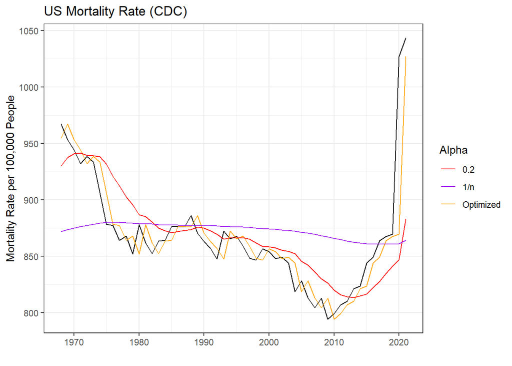

```r
# add new line to plot
pl <- pl +
  geom_line(
    data = models_dable |> filter(.model == "one_n"),
    aes(year, .fitted, col = "1/n")
  )

# show plot
pl
```

##### d) Which of the smoothing parameter values you tried before work best for the series? Justify your answer.

**NoteAnswer**

Each of these different parameters has different strengths and weaknesses. The SSP1E choice of parameter puts its focus on recent observations rather than historical observation. This parameter would be useful for trying to forecast the number of deaths in 2022 due to Covid. The smoothing parameter of 0.2 balances responsiveness and stability when forecasting mortality rates. This value allows the model to capture recent changes without overreacting to random fluctuations, providing a smoother, more reliable forecast. The smoothing parameter of 1/n places the most emphasis on historical data, which allows longer term trends to be visible. Remember, choosing the optimal smoothing parameter often involves considering the specific characteristics of the data, the purpose of the analysis and potential external influences.